# Лабораторная работа №5

Адресация IPv4 и IPv6.Настройка DHCP

Устинова В. В.

Российский университет дружбы народов, Москва, Россия

04 ноября 2026

# Информация

## Докладчик

- Устинова Виктория Вадимовна
- студент НПИбд-01-24
- Российский университет дружбы народов

# Вводная часть

## Цель работы

Получение навыков настройки службы DHCP на сетевом оборудовании для распределения адресов IPv4 и IPv6.

## Задание

1. Настроить на маршрутизаторе VyOS DHCP-сервер для распределения адресов IPv4 из диапазона 10.0.0.2–10.0.0.253, настроить получение адреса по DHCP на узле PC1 и исследовать пакеты DHCP.
2. Настроить на интерфейсе eth1 маршрутизатора DHCPv6 без отслеживания состояния, а на интерфейсе eth2 — DHCPv6 с отслеживанием состояния. Проверить получение настроек клиентами.

# Выполнение лабораторной работы

## Топология сети IPv4

В GNS3 построена топология: хост PC1-vvustinova подключён к коммутатору vvustinova-sw-01, который соединён с интерфейсом eth0 маршрутизатора vvustinova-gw-01 (VyOS).

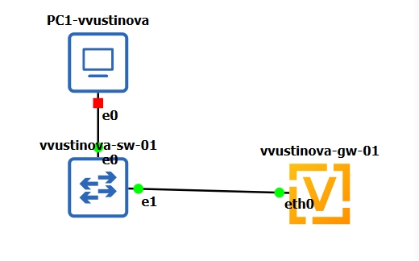

Топология сети для настройки DHCP IPv4

## Первоначальная настройка маршрутизатора

Изменены имя и доменное имя устройства, создан пользователь vvustinova и удалено получение адреса по DHCP на интерфейсе eth0. Конфигурация применена и сохранена.

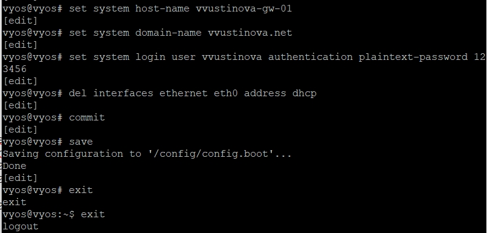

Первоначальная настройка маршрутизатора VyOS

## Замена пользователя

Выполнен вход под новым пользователем, системный пользователь vyos удалён.

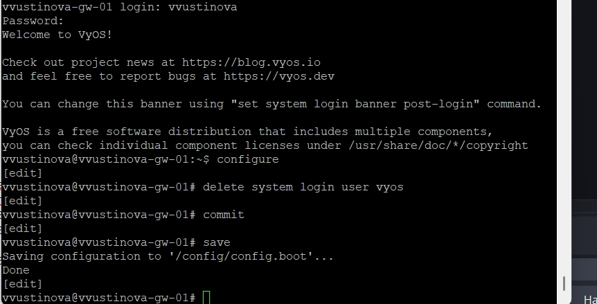

Вход под новым пользователем и удаление пользователя vyos

## DHCP-сервер

Интерфейсу eth0 назначен адрес 10.0.0.1/24. Настроены общая сеть vvustinova с доменом и DNS-сервером, подсеть 10.0.0.0/24 со шлюзом 10.0.0.1 и диапазон адресов, начинающийся с 10.0.0.2.

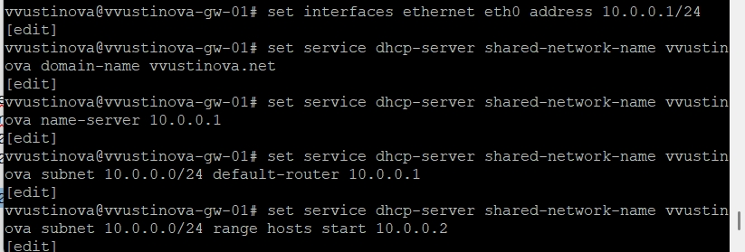

Настройка адреса интерфейса eth0 и DHCP-сервера

## Статистика DHCP-сервера

Пул vvustinova содержит 252 адреса (10.0.0.2–10.0.0.253). Выданных адресов пока нет, таблица аренды пуста.

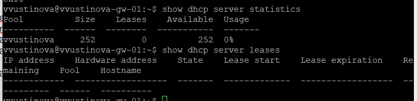

Статистика DHCP-сервера и список аренды до подключения клиента

## Настройки IPv4 на PC1

PC1 получил адрес 10.0.0.2/24, шлюз и DNS-сервер 10.0.0.1, домен vvustinova.net, время аренды 86400 с. Пинг маршрутизатора успешен.

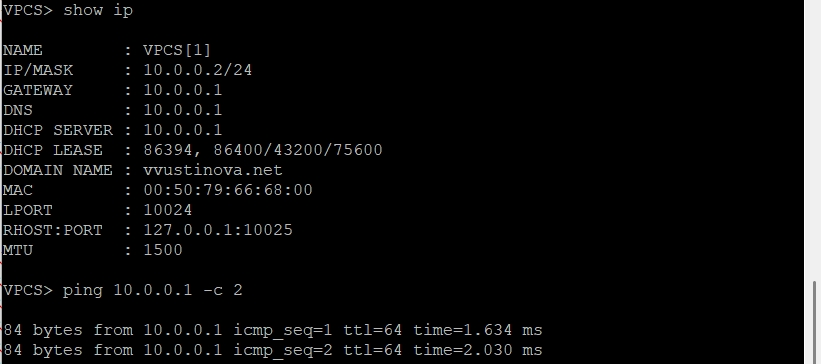

Параметры IPv4 на PC1, полученные по DHCP, и проверка связи с маршрутизатором

## Пакеты DHCP

Клиент рассылает широковещательные Discover (0.0.0.0 → 255.255.255.255, порты 68 и 67). Сервер отвечает Offer, клиент отправляет Request, сервер подтверждает аренду сообщением ACK.

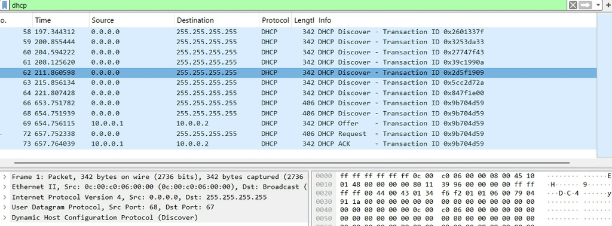

Пакеты DHCP в анализаторе трафика: Discover, Offer, Request, ACK

## Топология сети IPv6

К интерфейсу eth1 маршрутизатора через коммутатор sw-02 подключён узел Alpine-02, к интерфейсу eth2 через коммутатор sw-03 — узел Alpine-03.

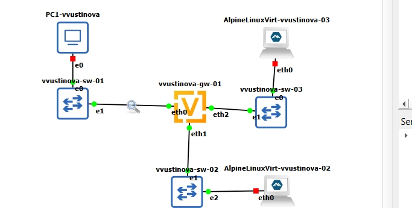

Топология сети для настройки DHCPv6

## Адресация IPv6 на маршрутизаторе

Интерфейсу eth1 назначен адрес 2000::1/64, интерфейсу eth2 — 2001::1/64, eth0 сохранил адрес 10.0.0.1/24.

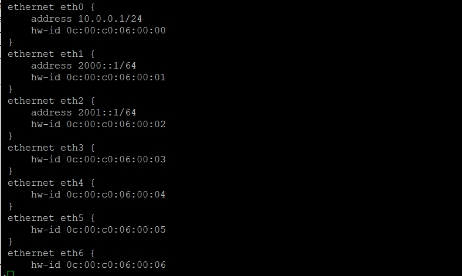

Адреса интерфейсов маршрутизатора

## DHCPv6 без отслеживания состояния

На eth1 настроено объявление маршрутизатора с префиксом 2000::/64 и флагом other-config-flag, создана общая сеть vvustinova-stateless с DNS-сервером 2000::1 и доменом поиска.

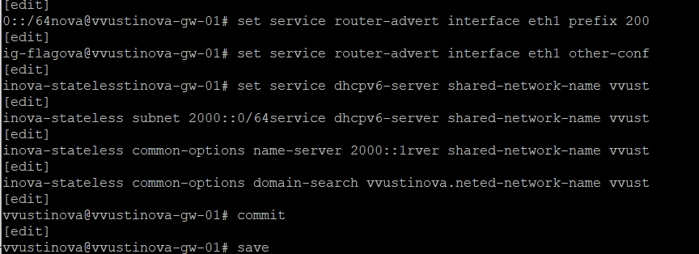

Настройка DHCPv6 без отслеживания состояния

## Настройки сети PC2

Узел PC2 сформировал глобальный адрес из префикса 2000::/64 и маршрут по умолчанию через link-local адрес маршрутизатора автоматически по объявлению маршрутизатора.

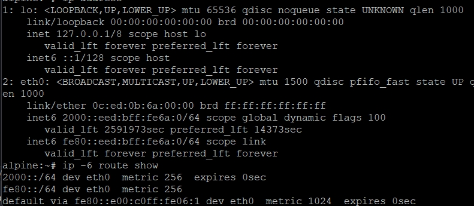

Настройки сети узла PC2

## Проверка связи и DNS на PC2

Пинг 2000::1 успешен. В resolv.conf остался прежний DNS-сервер 10.0.2.3: остальные параметры клиент должен запросить у DHCPv6-сервера отдельно.

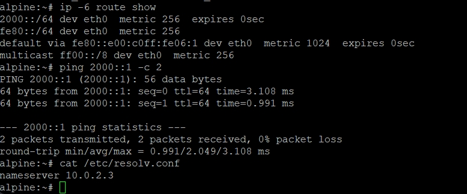

Проверка связи с маршрутизатором и настройки DNS на PC2

## DHCPv6 с отслеживанием состояния

Список аренды при настройке без отслеживания состояния пуст. На eth2 включён managed-flag, создана общая сеть vvustinova-stateful с подсетью 2001::/64 и диапазоном 2001::100–2001::199.

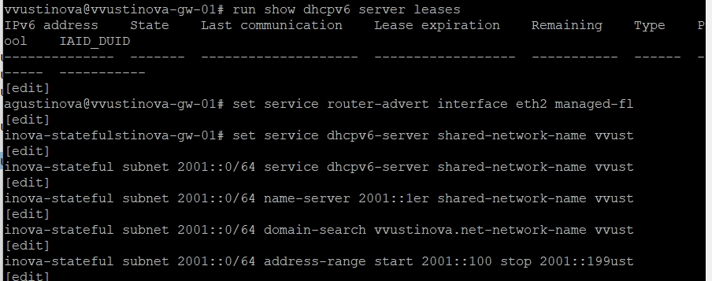

Пустой список аренды DHCPv6 и настройка DHCPv6 с отслеживанием состояния

## Настройки PC3

PC3 получил адрес по DHCPv6. Пинг 2001::1 успешен, в resolv.conf указаны домен vvustinova.net и DNS-сервер 2001::1.

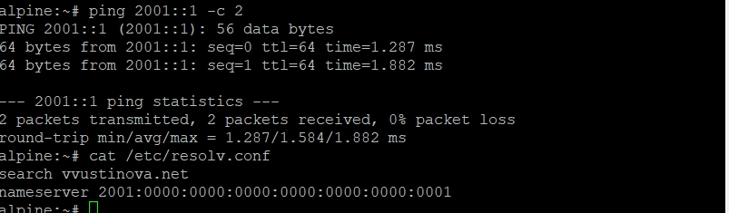

Проверка связи с маршрутизатором и настройки DNS на PC3 после получения адреса по DHCPv6

## Аренда на DHCPv6-сервере

В списке аренды адрес 2001::198 в состоянии active, тип non-temporary, пул vvustinova-stateful, срок аренды 12 часов. Сервер выделил адрес и отслеживает его.

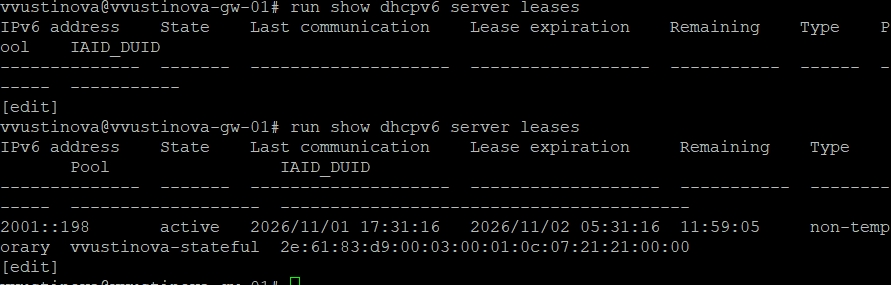

Аренда адреса IPv6 клиенту на DHCPv6-сервере

# Заключение

## Выводы

В ходе работы получены навыки настройки службы DHCP на маршрутизаторе VyOS для распределения адресов IPv4 и IPv6. Клиент PC1 получил адрес, шлюз и DNS-сервер от DHCP-сервера, а получение адреса прослеживается по пакетам Discover, Offer, Request и ACK. При настройке DHCPv6 без отслеживания состояния адрес формируется автоматически, а сервер аренду не ведёт. При настройке с отслеживанием состояния сервер выдаёт клиенту адрес из диапазона, передаёт параметры DNS и фиксирует аренду.